# Oregon DEQ Water Quality Status and Trends report for the Pistol River Strategic Implementation Area and Coordinated Streamside Management

January 2018

# 1 - Methods

## 1.1 Data Sources

Analysts retrieved data from [DEQ](http://www.oregon.gov/deq/wq/Pages/WQdata.aspx) (LASAR and ELEMENT), EPA ([Storet](https://www.epa.gov/waterdata/water-quality-data-wqx)) USGS ([NWIS](https://qwwebservices.usgs.gov/), [Water Quality Portal](https://www.waterqualitydata.us/), Storet) databases.A summary of all organizations that provided data that was queried and evaluated for use in this report is found in the Appendix. The time period for the query was from 2000-01-01 to 2018-01-01. Parameters included in the query were temperature, total suspended solids, total phosphorus, and bacteria. The data returned were evaluated for data quality. EPA and USGS data were included unless result comments indicated problems with the data. Recent data (after June 2014) from the USGS was marked as provisional data and included in this analysis.

## 1.2 Decision Criteria

Status and long-term trends of the data were assessed for evaluating water quality in relation to water quality criterion or TMDL allocations. A decision criterion has been created for selecting stations that had greater than eight years of data and/or data to address water quality status. Stations that fit the criteria were sent to DEQ basin coordinator for their input on stations in the basin that had sufficient data that was not in one of the queried databases and that should also be included in this analysis. Monitoring data from tribal lands were not included in this analysis. Dominant land use characteristics were used as a station descriptor, not a deciding factor.

# 2 - Analysis

DEQ compared pH results from both grab and continuous sample data to the water quality criterion. The bacteria standard is based on the presence of E. coli compared to a single sample maximum and a geometric mean of five or more samples in a 90 day period. The temperature standard is based on the calculation of the seven day average of the daily maximum stream temperatures. When applicable, total suspended solids and total phosphorus were compared to the TMDL load allocation. If no allocation was present, total suspended solid and total phosphorus result values were plotted over time. Trends for E. coli, total phosphorus, and total suspended solids were assessed using Seasonal Kendall Analysis, which removes the influence of season-to-season fluctuations . The Seasonal Kendall Analysis also indicates the statistical significance and slope of the trend [Hirsch et al. 1982](https://profile.usgs.gov/myscience/upload_folder/ci2012Oct1508260828033Techniques%20of%20Trend%20Analysis%20for%20Monthly%20Water%20Quality%20Data.pdf).

For temperature trend analysis, analysts used data only from stations with eight years of continuous hourly temperature data in each month during the query period. Data were not used if observations were missing for more than one day each month or if fewer than 22 hourly measurements were recorded during the day. These criteria resulted in no more than 10% missing data across each of the temporal periods of interest. Fish use and spawning maps were used to determine the applicable temperature standards for the spawning and non-spawning time periods.

The results of this report includes graphs for stations with data that exceeded a water quality criterion more than once and/or showed a positive or negative trend. When insufficient data were available, that was noted in the graphs.

# 3 - Results

## 3.1 - Station Locations

Within the Chetco 8-digit HUC (17100312), 21 out of 65 monitoring stations fit the criteria to assess water quality status and trends. The following map shows monitoring stations that fit the criteria within the watershed. Use box on the right side of the figure to choose between background layers.

### 3.1.1 Stations with sufficient data for assessment of status and/or trends

[interactive chart not shown]

### 3.1.2 All stations in query

[interactive chart not shown]

## 3.2 Land Use

Each monitoring station that fit the criteria to assess water quality status and/or trends was included in the land use analysis. The Stream-Catchment ([StreamCat](https://www.epa.gov/national-aquatic-resource-surveys/streamcat)) developed by EPA was used to summarize the cumulative upstream catchment of each station for primary landuse characteristics, based on the National Hydrography Dataset Plus Version 2 geospatial framework.

*Summary table of watershed land use by station, only stations which have at least 8 years of yearly data (between 2000 and 2017) and/or are used to evaluate last known status. Source: 2011 NLCD*

| Station ID | Station Description | Watershed Area (km<sup>2</sup>) | %Urban | %Forest | %Ag | %Range | %Other |
| --- | --- | --- | --- | --- | --- | --- | --- |
| 11493 | Pistol River at Pistol River Loop Road | 265 | 3 | 81 | 0 | 14 | 1 |
| 10537 | Winchuck River 1.3 miles upstream of Hwy 101 | 156 | 4 | 89 | 0 | 7 | 1 |
| 11483 | Chetco River at USGS Gage (10 miles upstream of Brookings) | 703 | 2 | 80 | 0 | 18 | 0 |
| 21ORBCH-29313 | Harris Beach State Park West of parking lot | 5 | 37 | 36 | 0 | 25 | 1 |
| 21ORBCH-30935 | Macklyn Creek upstream | 4 | 91 | 4 | 0 | 3 | 2 |
| 21ORBCH-31559 | Harris Creek upstream | 4 | 28 | 42 | 0 | 28 | 2 |
| 21ORBCH-31687 | Mill Beach at Macklyn Creek | 4 | 91 | 4 | 0 | 3 | 2 |
| 29312 | Harris Beach State Park day use area, north cove at Harris Creek | 4 | 29 | 44 | 0 | 26 | 1 |
| 29313 | Harris Beach State Park day use, south cove west of parking lot | 5 | 37 | 36 | 0 | 25 | 1 |
| 30935 | Macklyn Creek 50m upstream from mouth | 4 | 91 | 4 | 0 | 3 | 2 |
| 31559 | Harris Cr 100m upstream from mouth | 4 | 28 | 42 | 0 | 28 | 2 |
| 31687 | Mill Beach at Macklyn Cr | 4 | 91 | 4 | 0 | 3 | 2 |

## 3.3 Water Quality Limited Stream Segments

*Summary of Oregon’s 2012 Integrated Report Assessment database and 303(d) list for parameters included in this report. Table based on the 2012 Integrated Report Listings by the EPA*

| Waterbody | Miles | Pollutant | Season | Year Assessed | Criteria | Listing Status |
| --- | --- | --- | --- | --- | --- | --- |

*Assessment Categories: Cat 4A: Water quality limited, TMDL approved; Cat 5: Water quality limited, 303(d) list, TMDL needed*

## 3.4 Seasonal Kendall Trend Analysis

*Output for the Seasonal Kendall analysis, which was performed to assess trends on data that had at least 8 years of data between 2000 and 2017. Only stations used in this analysis are included in this table. The values in the N column represent the number of results for each analyte at each monitoring station and includes duplicate values. If no table is present, no stations have enough data (>8 years) to assess trends.*

## 3.5 E.coli

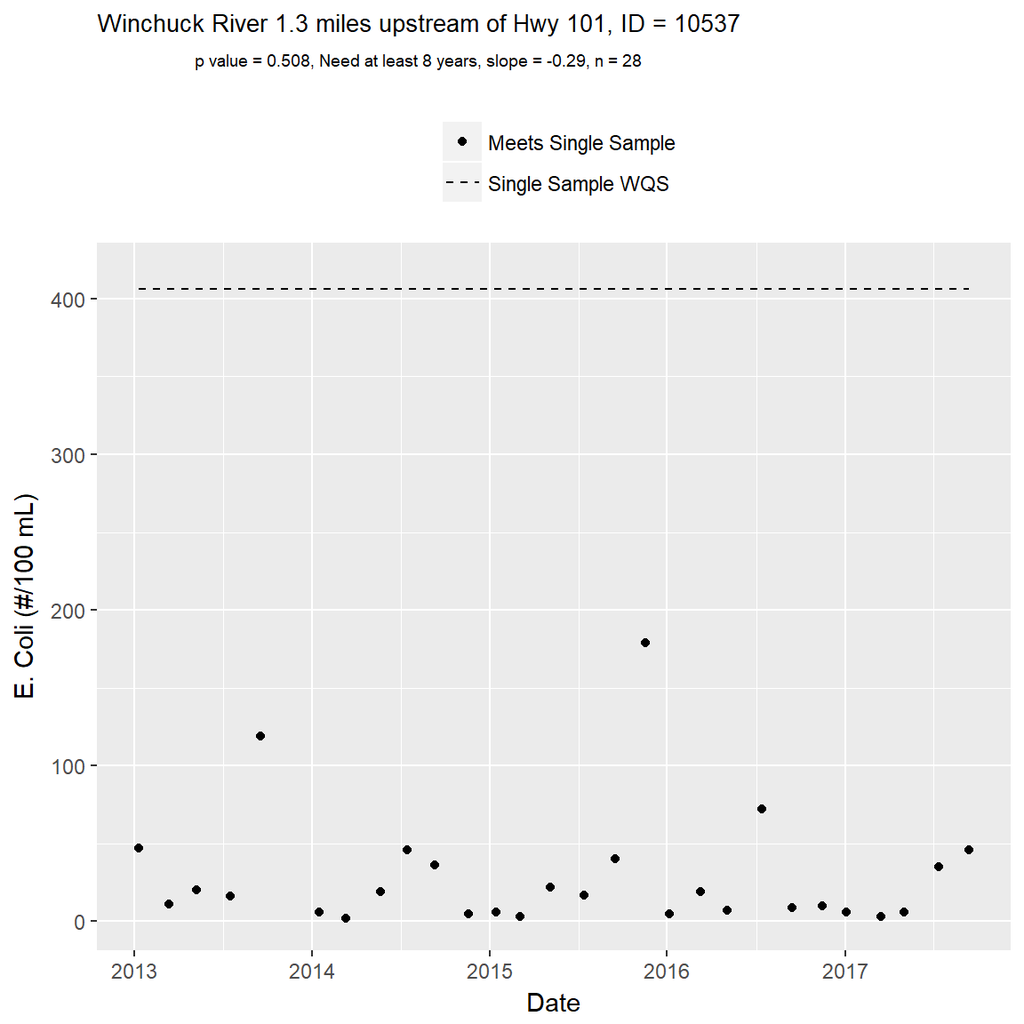

*E. Coli* water quality status and trends

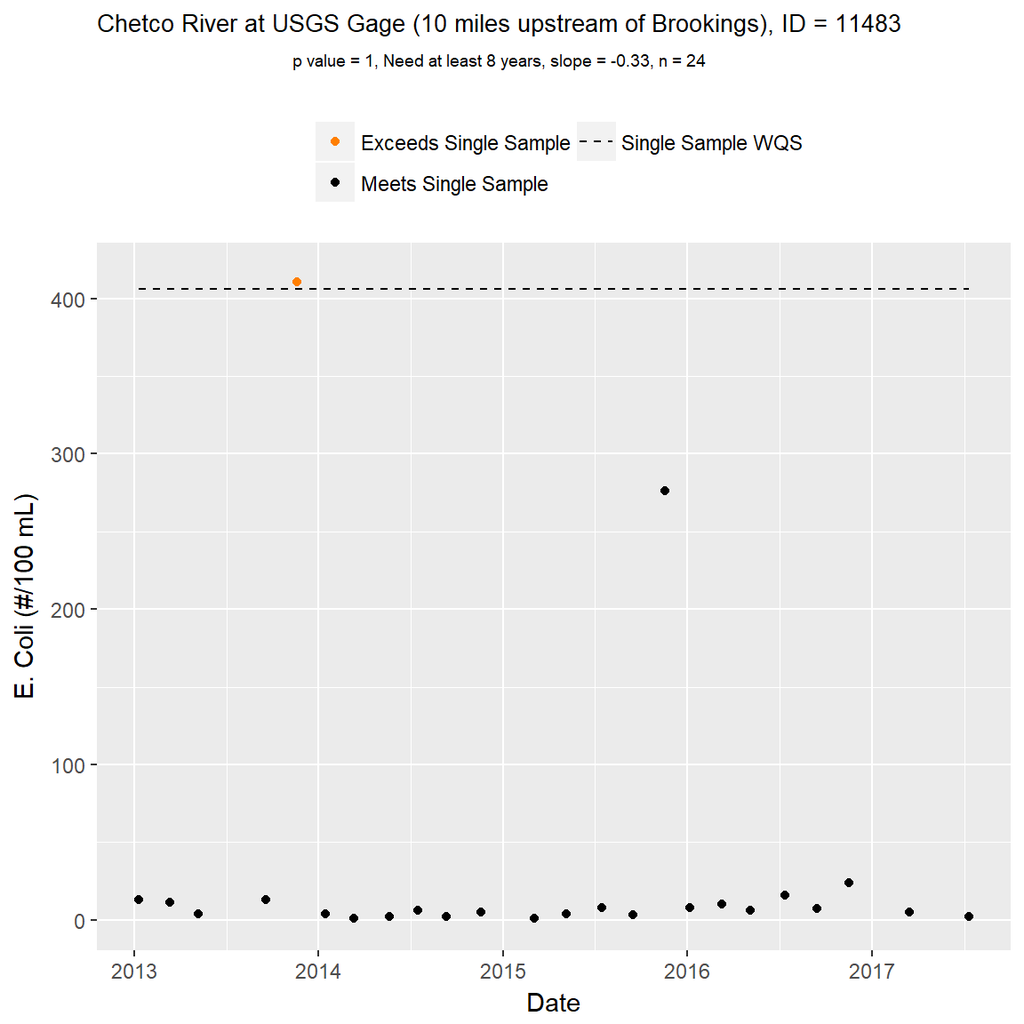

*E. Coli* water quality status and trends

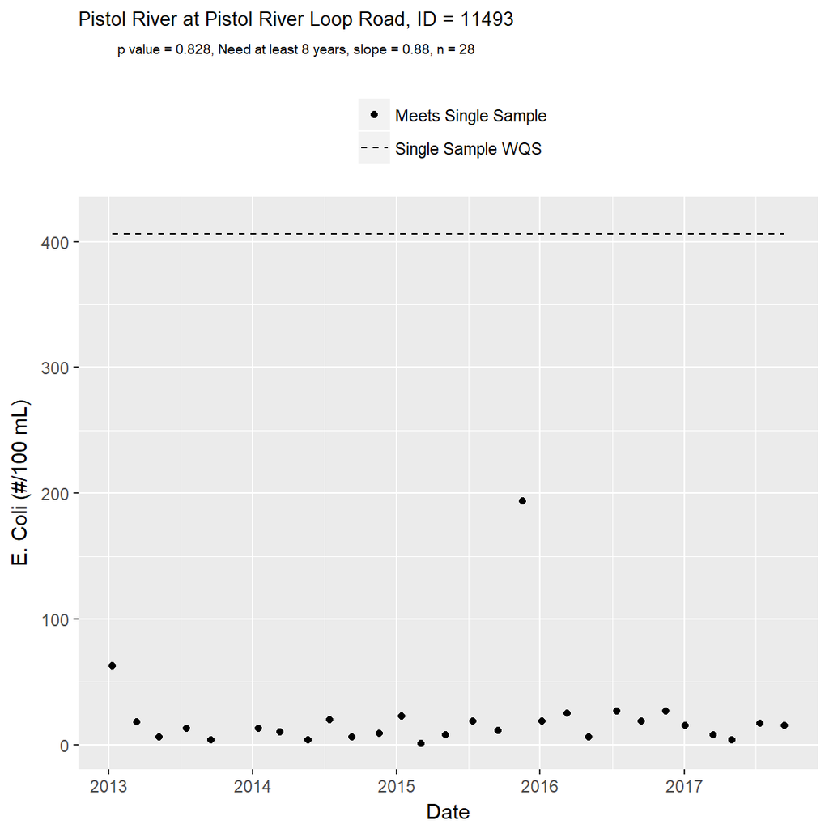

*E. Coli* water quality status and trends

| Station ID | Station Description | Sample | Obs | Exceedances | % Exceedance |
| --- | --- | --- | --- | --- | --- |
| 10537 | Winchuck River 1.3 miles upstream of Hwy 101 | Single sample | 28 | 0 | 0.0 |
| 10537 | Winchuck River 1.3 miles upstream of Hwy 101 | Geomean | 0 | 0 | NaN |
| 11483 | Chetco River at USGS Gage (10 miles upstream of Brookings) | Single sample | 24 | 1 | 4.2 |
| 11483 | Chetco River at USGS Gage (10 miles upstream of Brookings) | Geomean | 0 | 0 | NaN |
| 11493 | Pistol River at Pistol River Loop Road | Single sample | 28 | 0 | 0.0 |
| 11493 | Pistol River at Pistol River Loop Road | Geomean | 0 | 0 | NaN |

## 3.6 Enterococcus

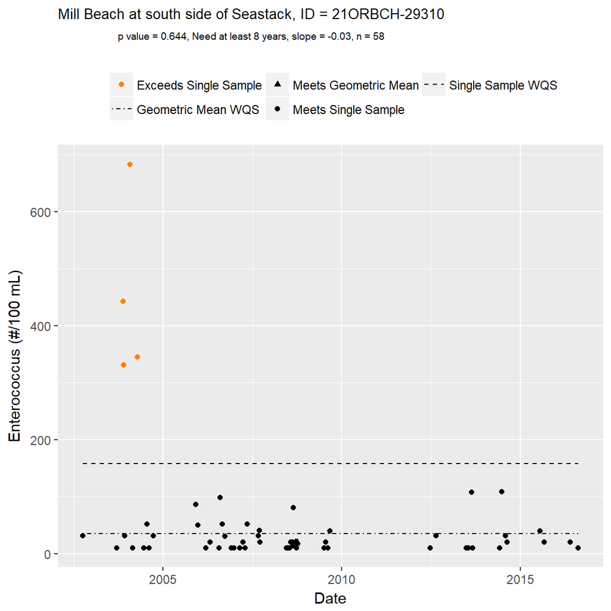

Enterococcus water quality status and trends

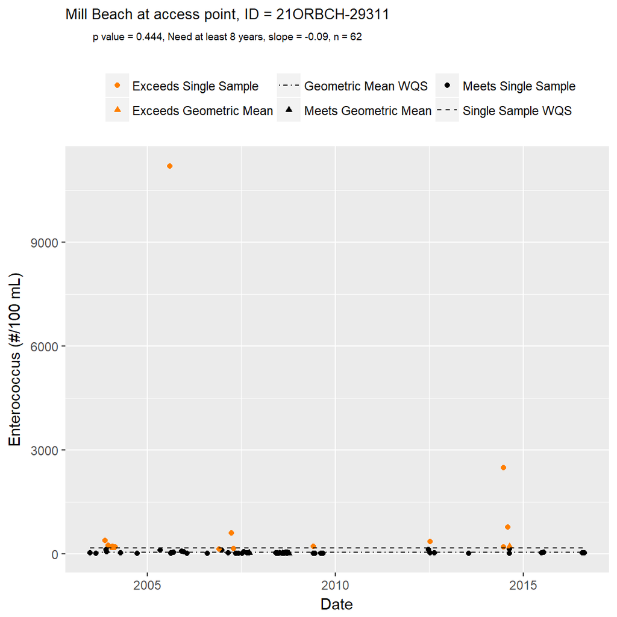

Enterococcus water quality status and trends

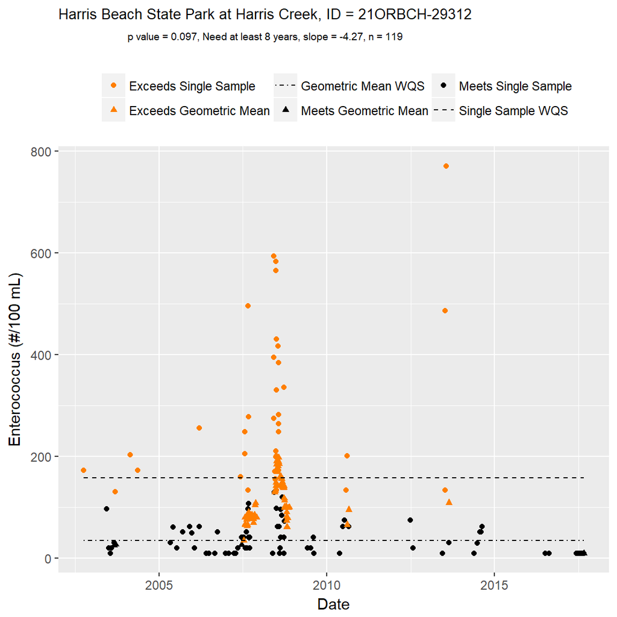

Enterococcus water quality status and trends

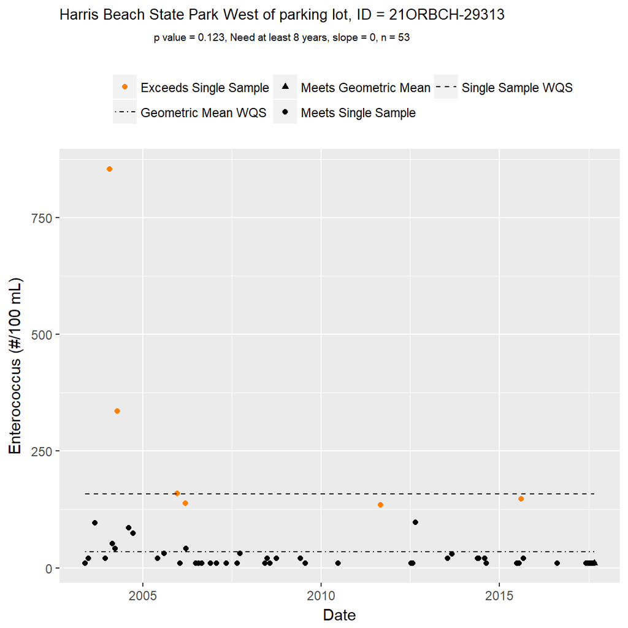

Enterococcus water quality status and trends

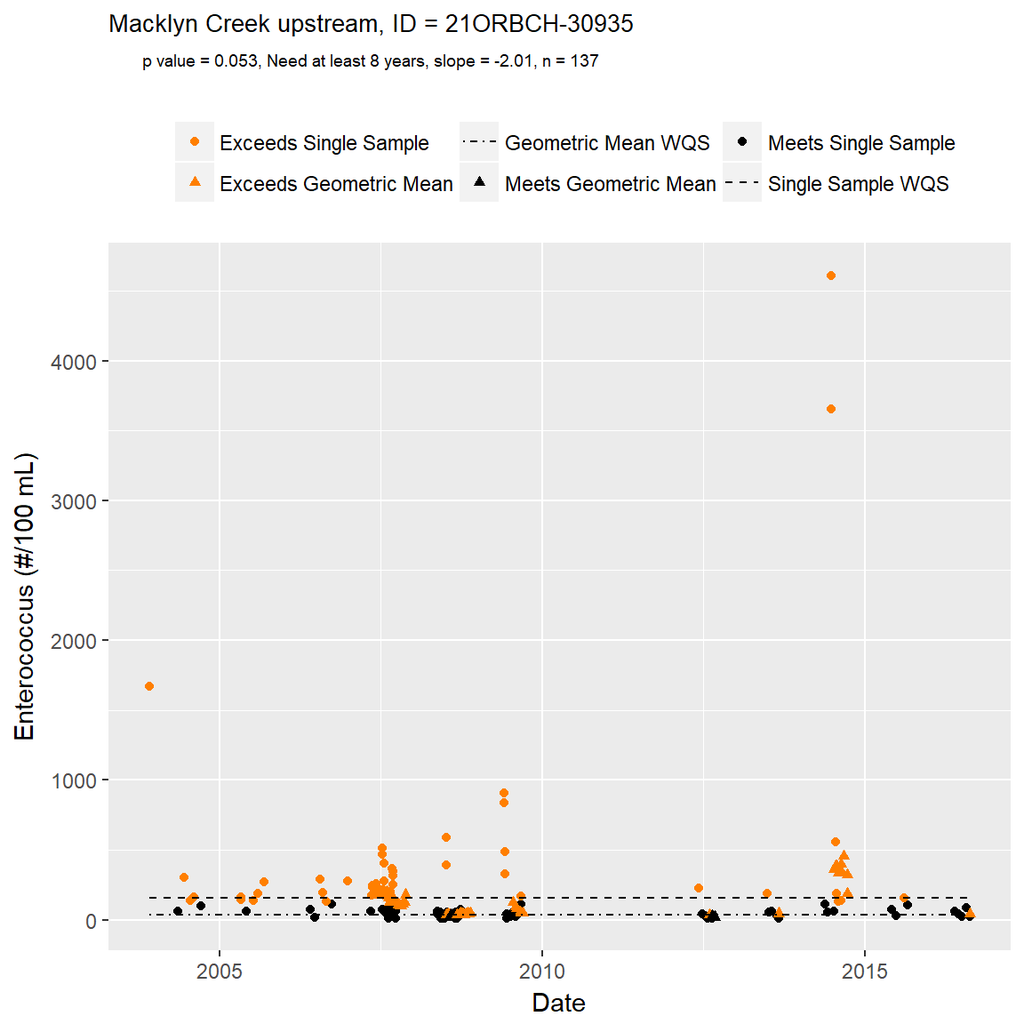

Enterococcus water quality status and trends

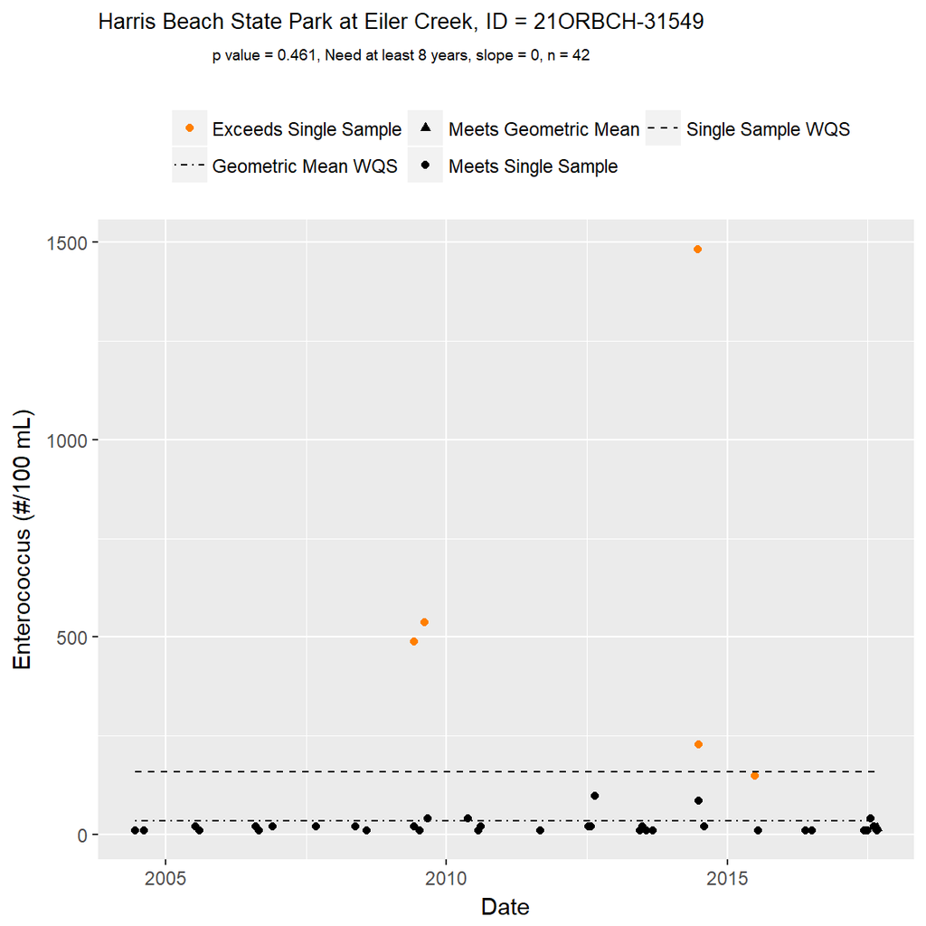

Enterococcus water quality status and trends

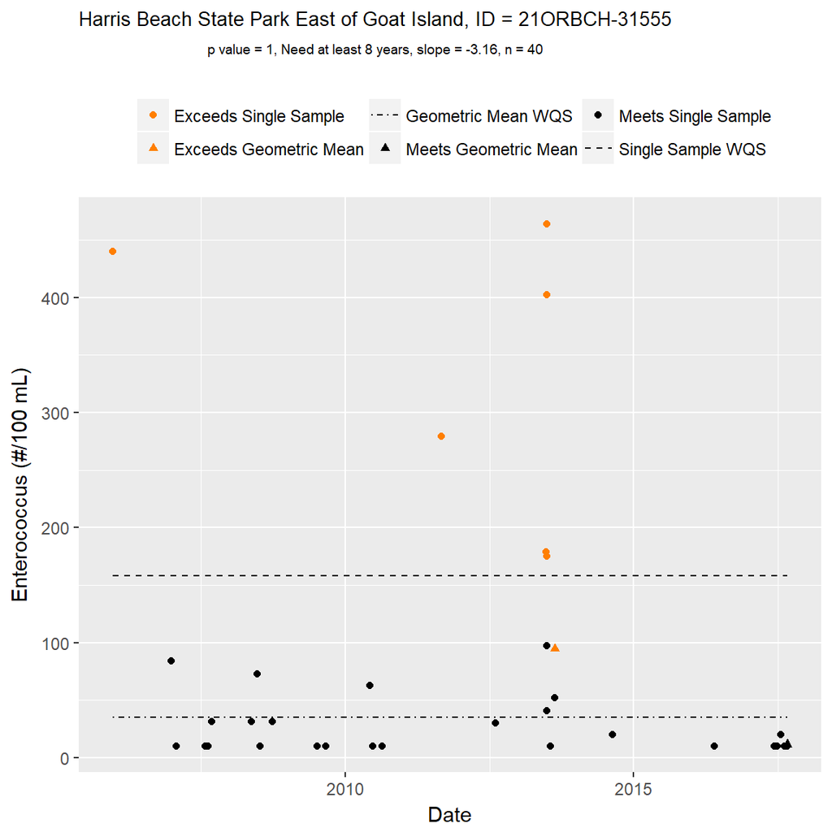

Enterococcus water quality status and trends

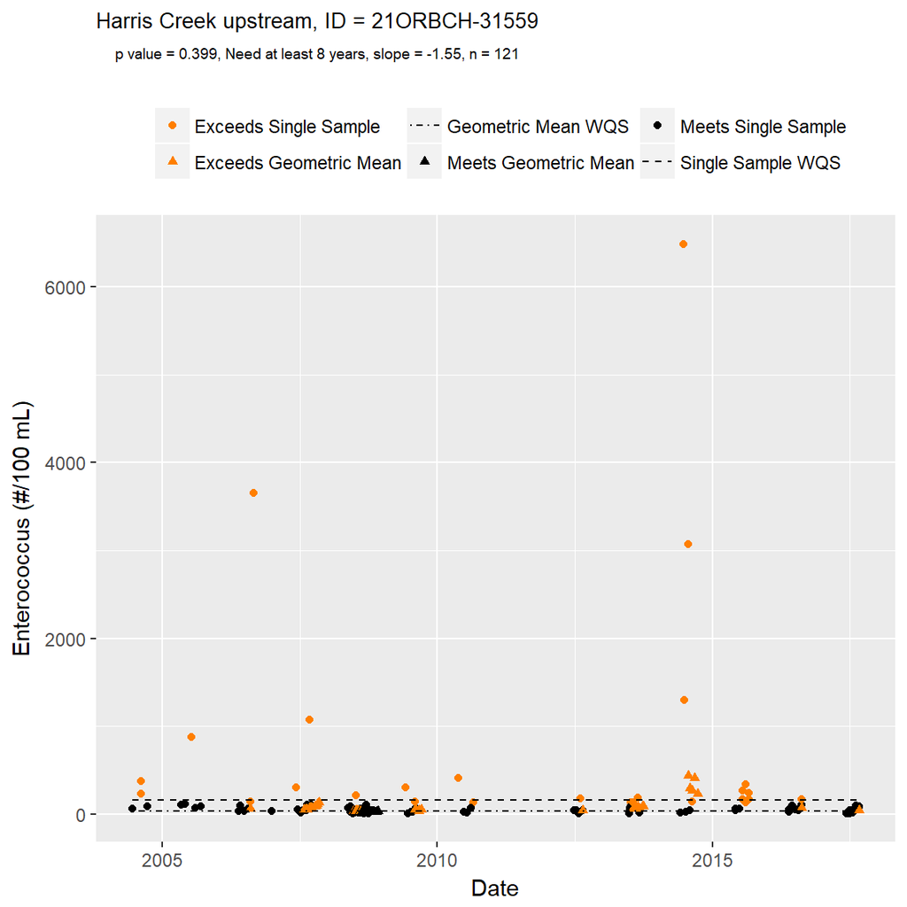

Enterococcus water quality status and trends

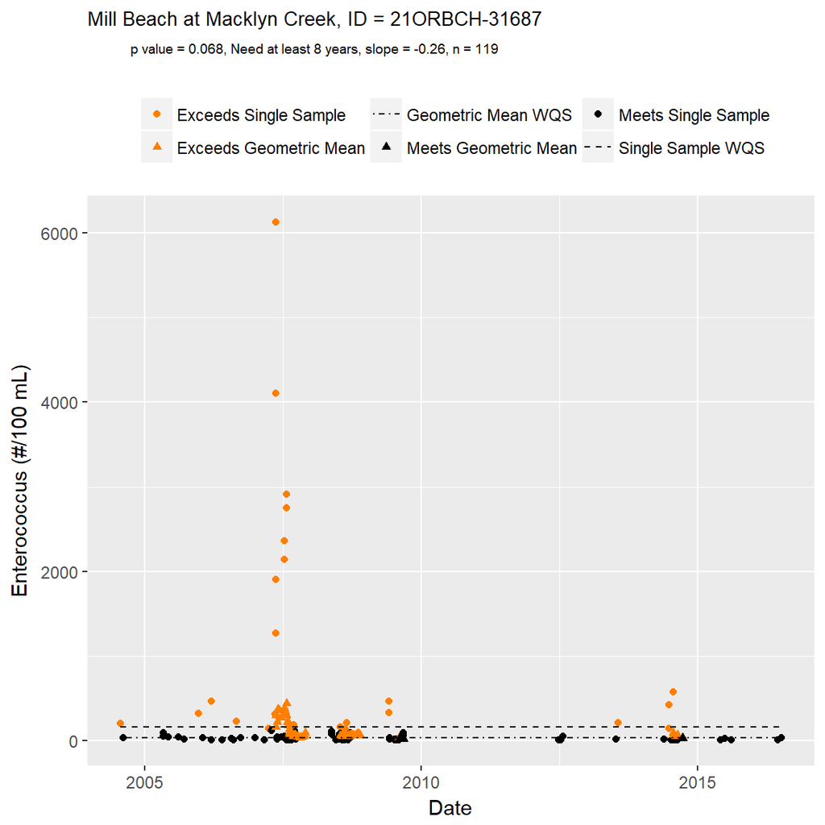

Enterococcus water quality status and trends

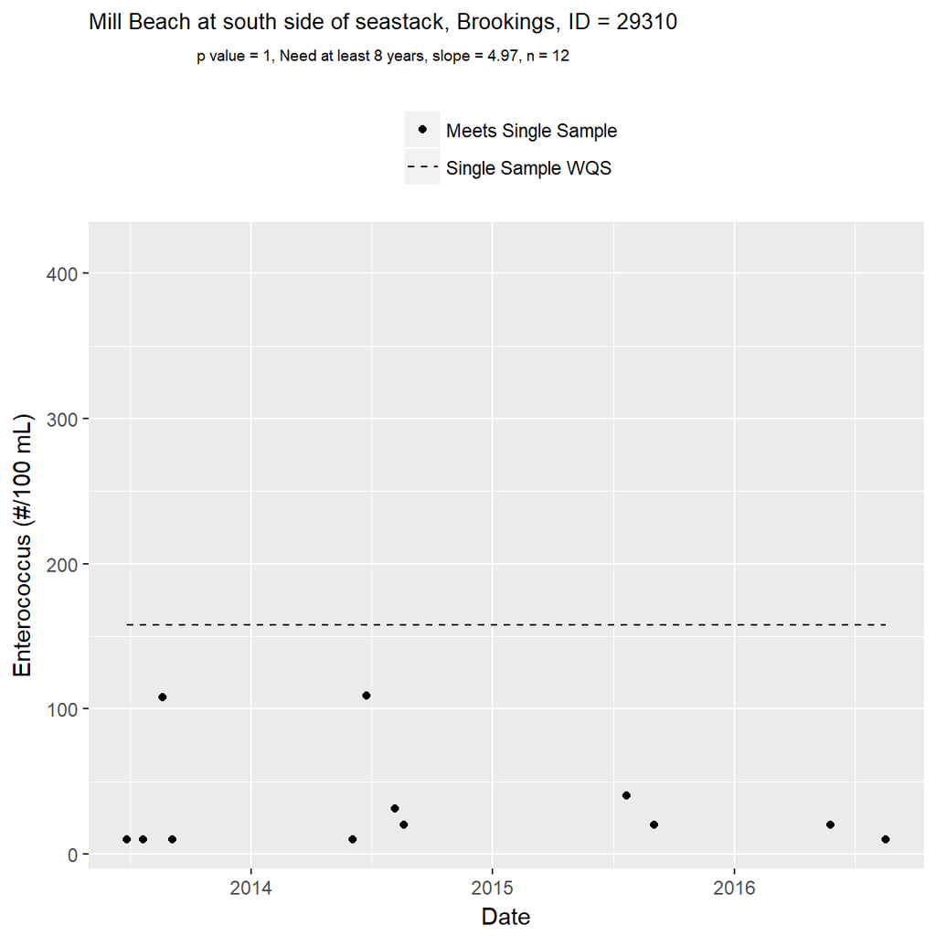

Enterococcus water quality status and trends

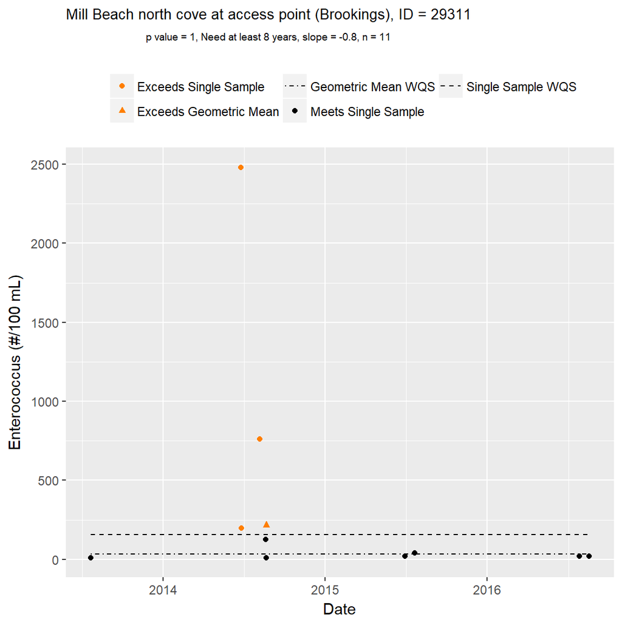

Enterococcus water quality status and trends

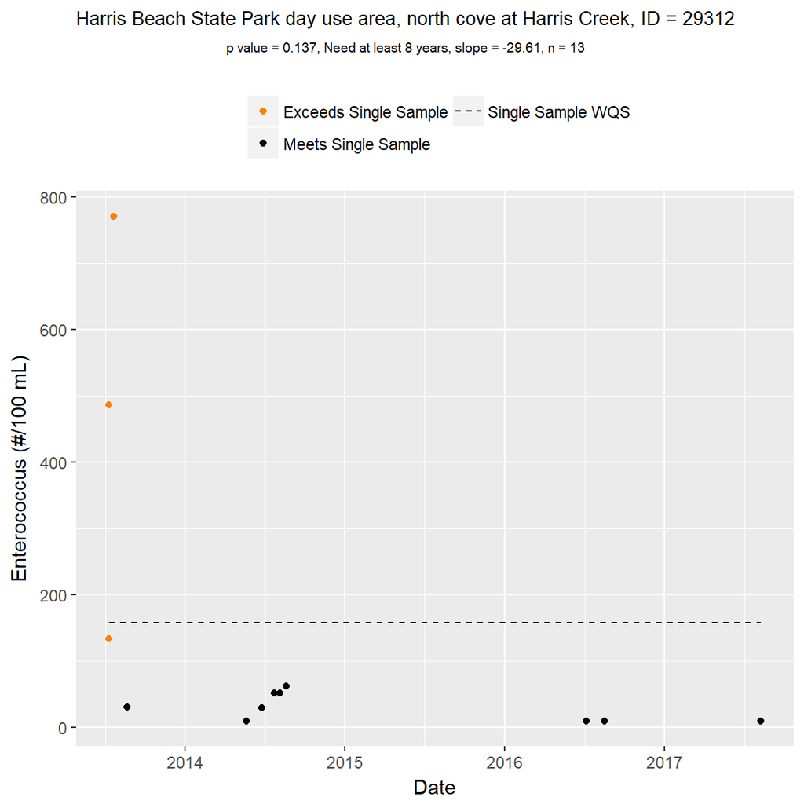

Enterococcus water quality status and trends

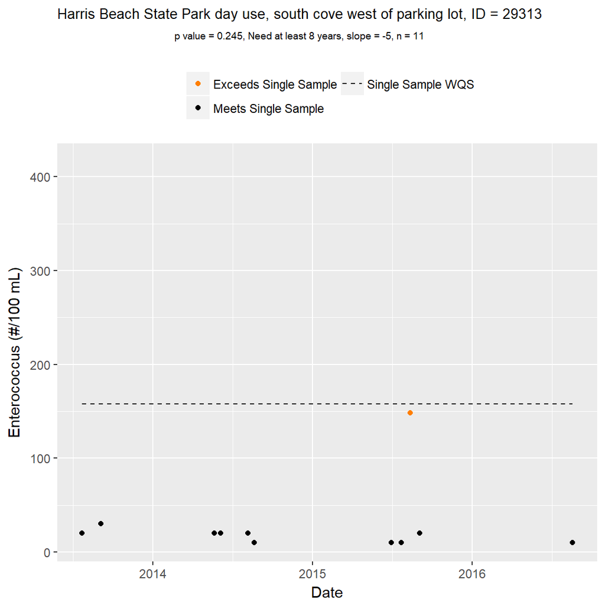

Enterococcus water quality status and trends

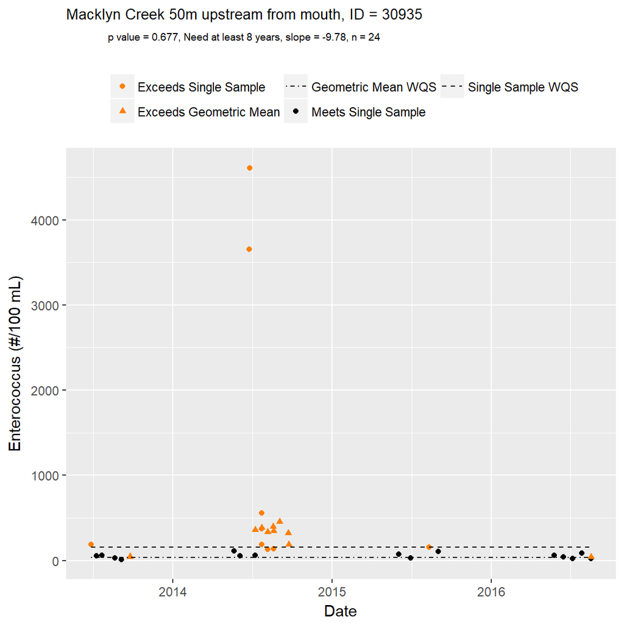

Enterococcus water quality status and trends

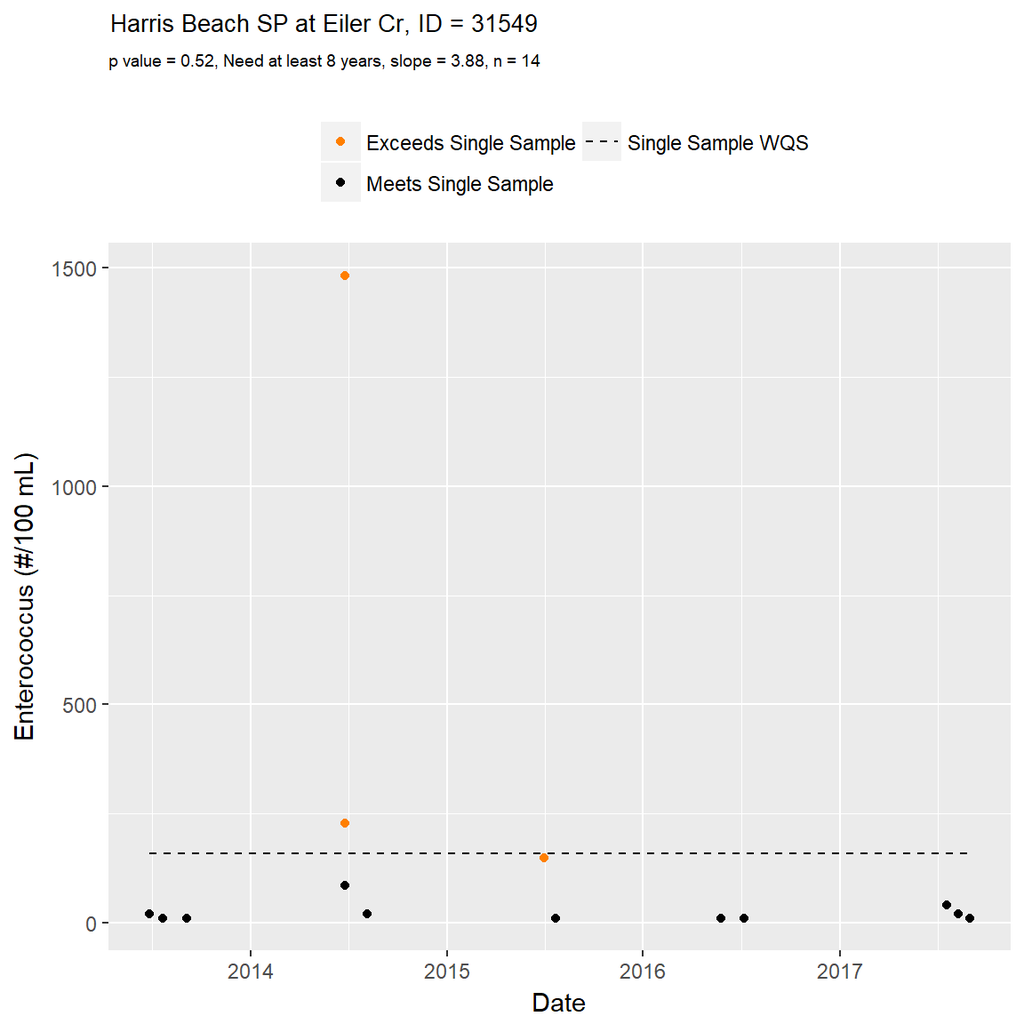

Enterococcus water quality status and trends

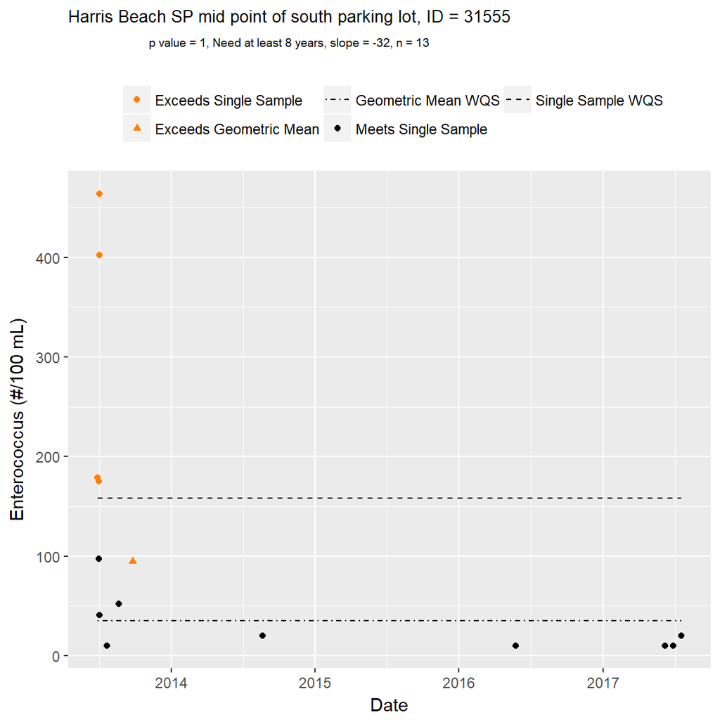

Enterococcus water quality status and trends

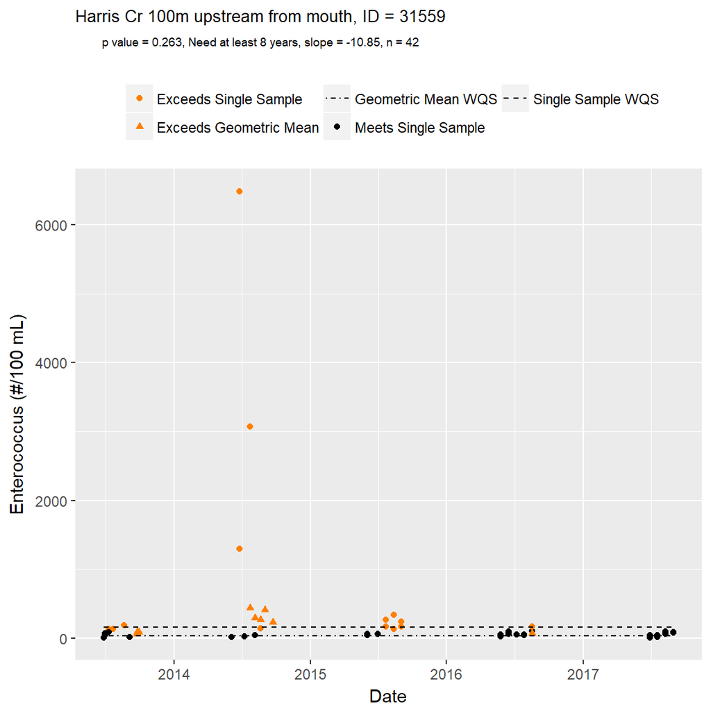

Enterococcus water quality status and trends

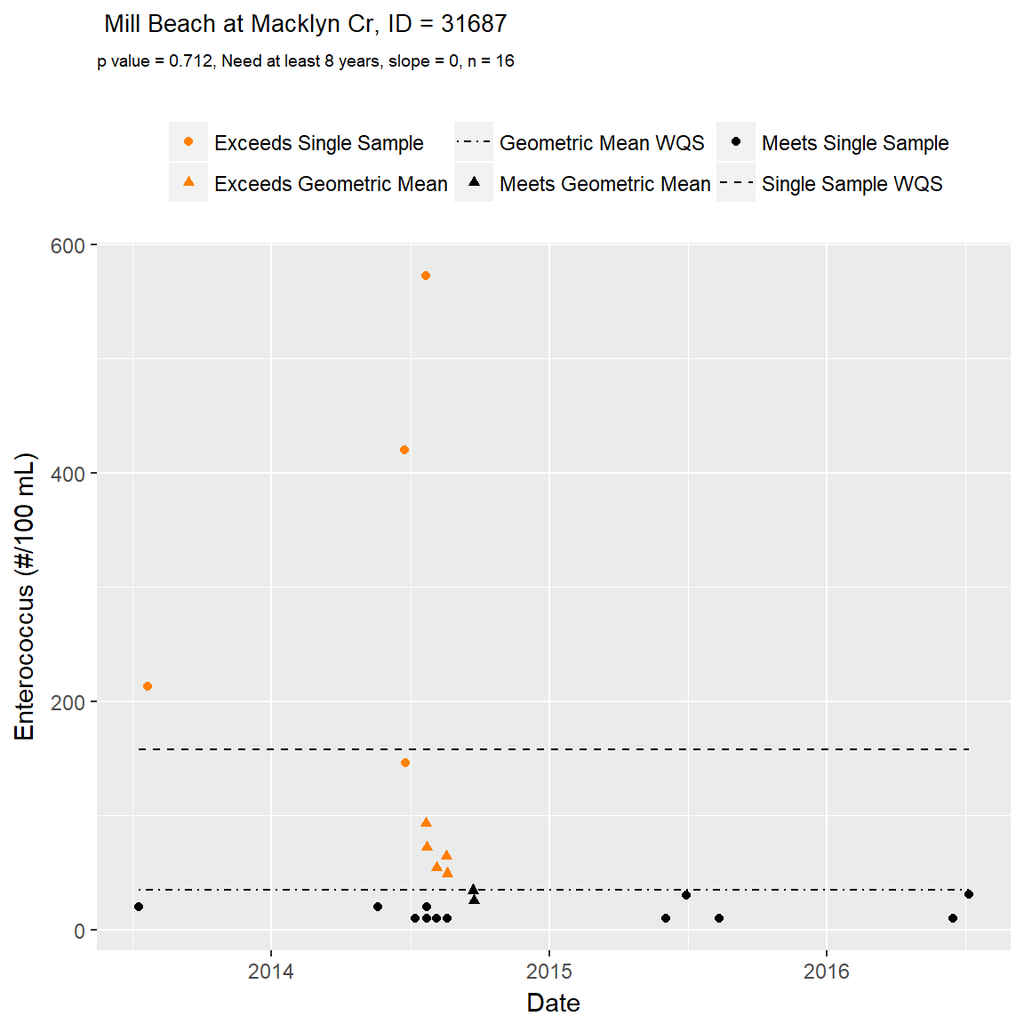

Enterococcus water quality status and trends

| Station ID | Station Description | Sample | Obs | Exceedances | % Exceedance |
| --- | --- | --- | --- | --- | --- |
| 21ORBCH-29310 | Mill Beach at south side of Seastack | Single sample | 58 | 4 | 6.9 |
| 21ORBCH-29310 | Mill Beach at south side of Seastack | Geomean | 5 | 0 | 0.0 |
| 21ORBCH-29311 | Mill Beach at access point | Single sample | 62 | 13 | 21.0 |
| 21ORBCH-29311 | Mill Beach at access point | Geomean | 14 | 2 | 14.3 |
| 21ORBCH-29312 | Harris Beach State Park at Harris Creek | Single sample | 119 | 42 | 35.3 |
| 21ORBCH-29312 | Harris Beach State Park at Harris Creek | Geomean | 68 | 64 | 94.1 |
| 21ORBCH-29313 | Harris Beach State Park West of parking lot | Single sample | 53 | 6 | 11.3 |
| 21ORBCH-29313 | Harris Beach State Park West of parking lot | Geomean | 1 | 0 | 0.0 |
| 21ORBCH-30935 | Macklyn Creek upstream | Single sample | 137 | 52 | 38.0 |
| 21ORBCH-30935 | Macklyn Creek upstream | Geomean | 70 | 62 | 88.6 |
| 21ORBCH-31549 | Harris Beach State Park at Eiler Creek | Single sample | 42 | 5 | 11.9 |
| 21ORBCH-31549 | Harris Beach State Park at Eiler Creek | Geomean | 1 | 0 | 0.0 |
| 21ORBCH-31555 | Harris Beach State Park East of Goat Island | Single sample | 40 | 10 | 25.0 |
| 21ORBCH-31555 | Harris Beach State Park East of Goat Island | Geomean | 2 | 1 | 50.0 |
| 21ORBCH-31559 | Harris Creek upstream | Single sample | 121 | 30 | 24.8 |
| 21ORBCH-31559 | Harris Creek upstream | Geomean | 66 | 42 | 63.6 |
| 21ORBCH-31687 | Mill Beach at Macklyn Creek | Single sample | 119 | 29 | 24.4 |
| 21ORBCH-31687 | Mill Beach at Macklyn Creek | Geomean | 70 | 64 | 91.4 |
| 29310 | Mill Beach at south side of seastack, Brookings | Single sample | 12 | 0 | 0.0 |
| 29310 | Mill Beach at south side of seastack, Brookings | Geomean | 0 | 0 | NaN |
| 29311 | Mill Beach north cove at access point (Brookings) | Single sample | 11 | 3 | 27.3 |
| 29311 | Mill Beach north cove at access point (Brookings) | Geomean | 1 | 1 | 100.0 |
| 29312 | Harris Beach State Park day use area, north cove at Harris Creek | Single sample | 13 | 3 | 23.1 |
| 29312 | Harris Beach State Park day use area, north cove at Harris Creek | Geomean | 0 | 0 | NaN |
| 29313 | Harris Beach State Park day use, south cove west of parking lot | Single sample | 11 | 1 | 9.1 |
| 29313 | Harris Beach State Park day use, south cove west of parking lot | Geomean | 0 | 0 | NaN |
| 30935 | Macklyn Creek 50m upstream from mouth | Single sample | 24 | 9 | 37.5 |
| 30935 | Macklyn Creek 50m upstream from mouth | Geomean | 11 | 11 | 100.0 |
| 31549 | Harris Beach SP at Eiler Cr | Single sample | 14 | 3 | 21.4 |
| 31549 | Harris Beach SP at Eiler Creek | Geomean | 0 | 0 | NaN |
| 31549 | Harris Beach SP at Eiler Cr | Single sample | 14 | 3 | 21.4 |
| 31549 | Harris Beach SP at Eiler Creek | Geomean | 0 | 0 | NaN |
| 31555 | Harris Beach SP mid point of south parking lot | Single sample | 13 | 4 | 30.8 |
| 31555 | Harris Beach SP mid point of south parking lot | Geomean | 1 | 1 | 100.0 |
| 31559 | Harris Cr 100m upstream from mouth | Single sample | 42 | 14 | 33.3 |
| 31559 | Harris Cr 100m upstream from mouth | Geomean | 9 | 9 | 100.0 |
| 31687 | Mill Beach at Macklyn Cr | Single sample | 16 | 4 | 25.0 |
| 31687 | Mill Beach at Macklyn Cr | Geomean | 7 | 5 | 71.4 |

## 3.7 Total Phosphorus

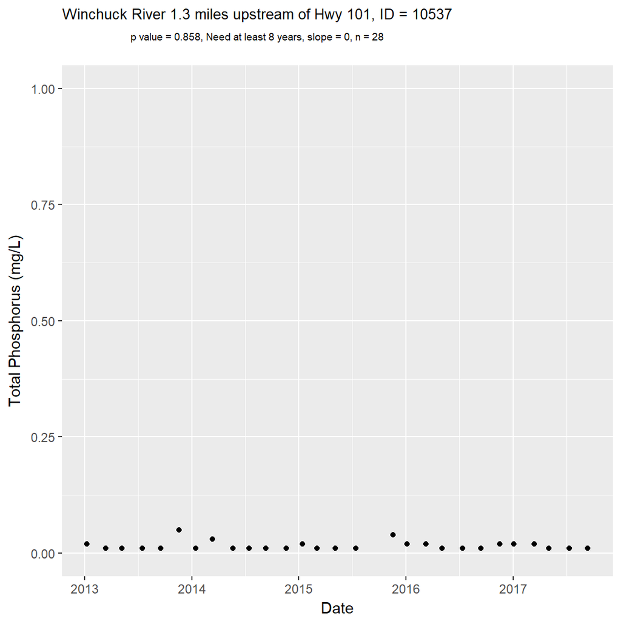

Total phosphorus water quality status and trends

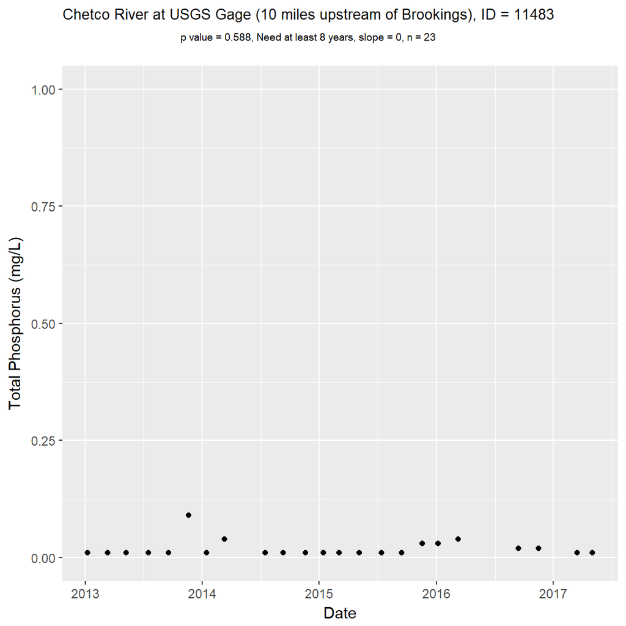

Total phosphorus water quality status and trends

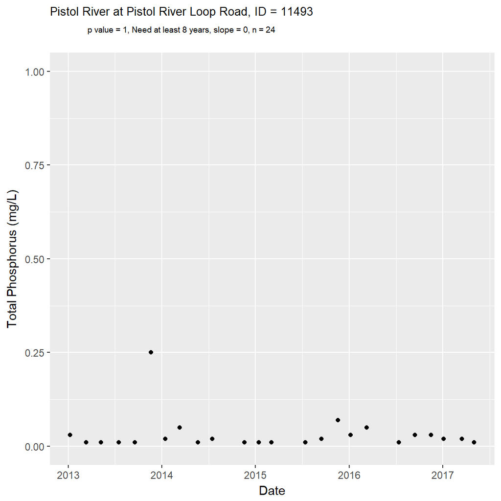

Total phosphorus water quality status and trends

| Station ID | Station Description | Min Date | Max Date | Obs |
| --- | --- | --- | --- | --- |
| 10537 | Winchuck River 1.3 miles upstream of Hwy 101 | 2013 | 2017 | 28 |
| 11483 | Chetco River at USGS Gage (10 miles upstream of Brookings) | 2013 | 2017 | 23 |
| 11493 | Pistol River at Pistol River Loop Road | 2013 | 2017 | 24 |

## 3.8 Total Suspended Solids

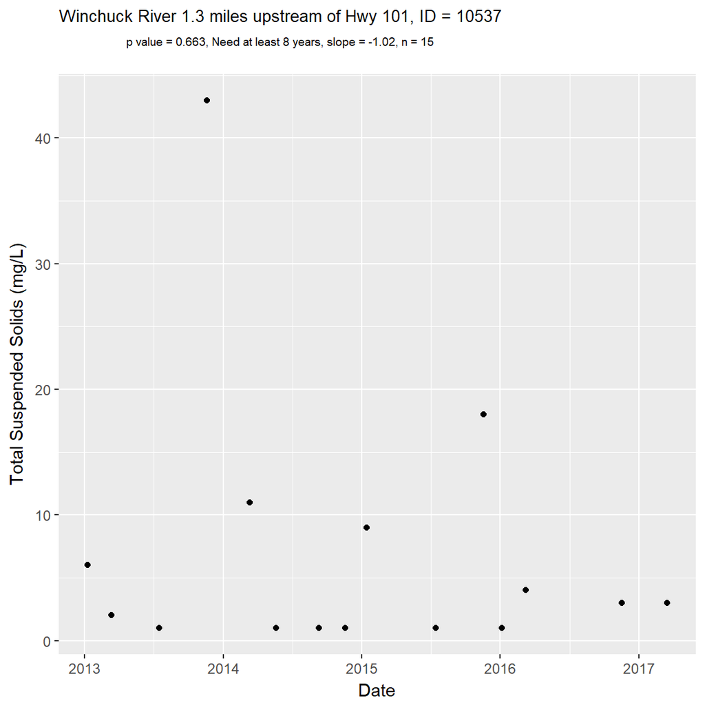

Total Suspended Solids water quality status and trends

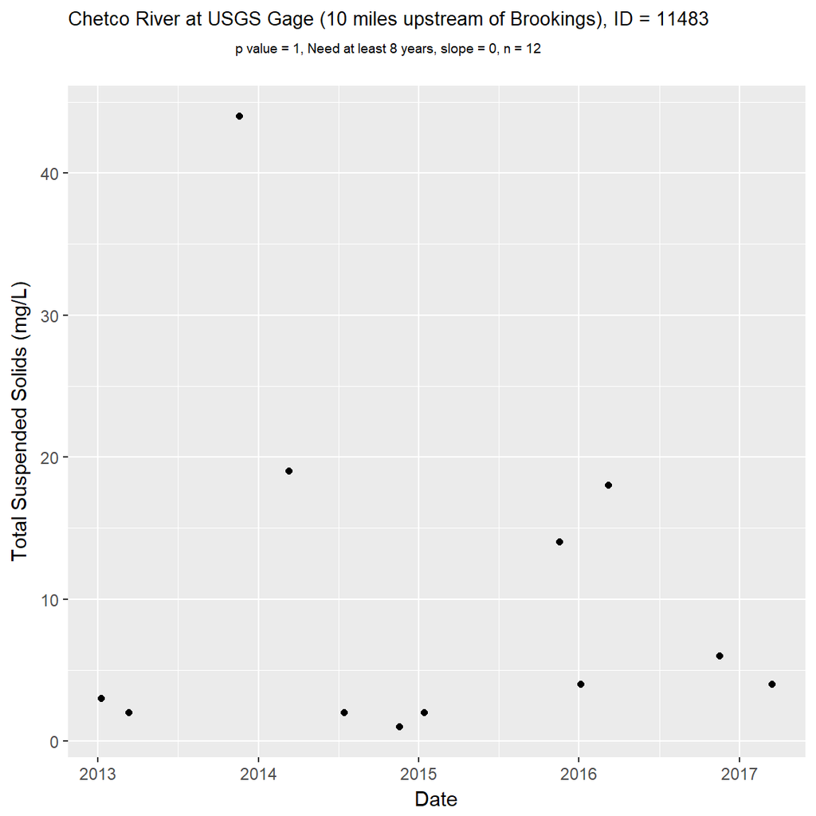

Total Suspended Solids water quality status and trends

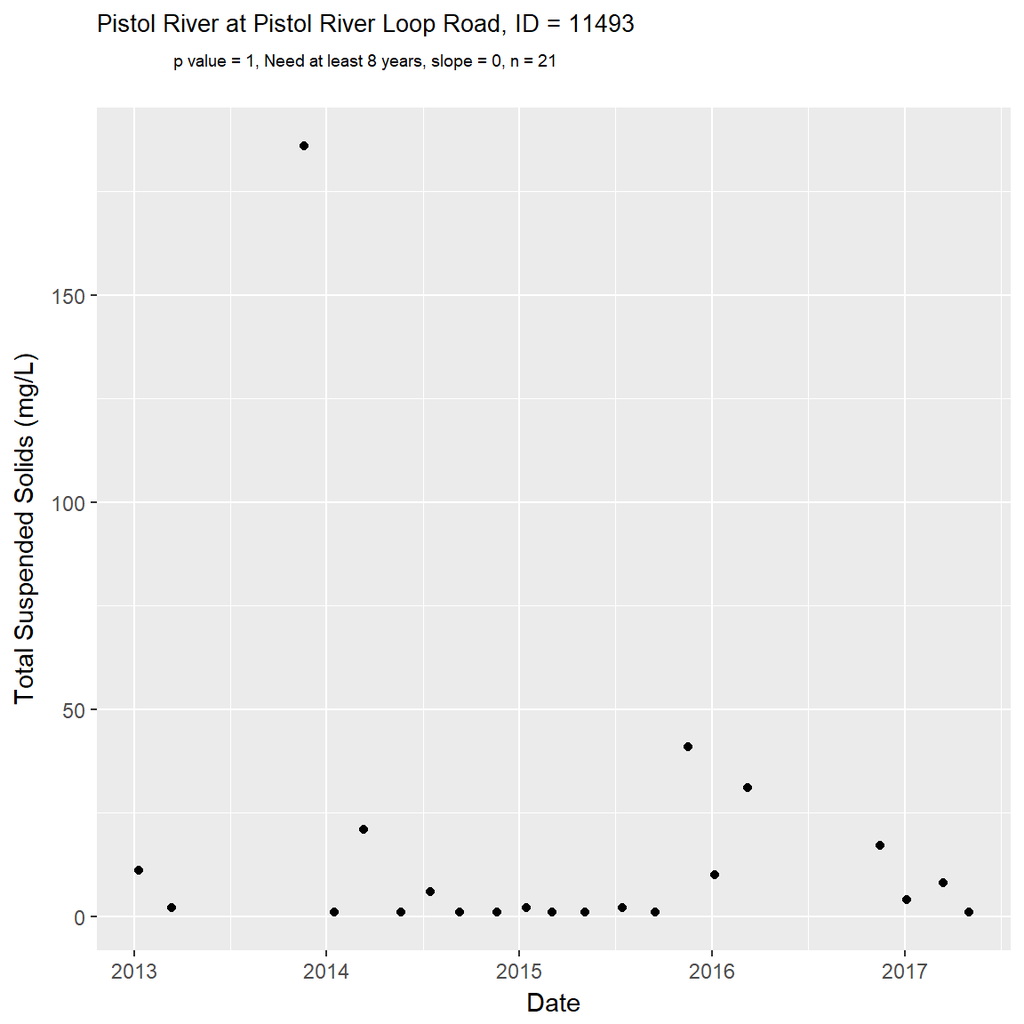

Total Suspended Solids water quality status and trends

| Station ID | Station Description | Min Date | Max Date | Obs |
| --- | --- | --- | --- | --- |
| 10537 | Winchuck River 1.3 miles upstream of Hwy 101 | 2013 | 2017 | 15 |
| 11483 | Chetco River at USGS Gage (10 miles upstream of Brookings) | 2013 | 2017 | 12 |
| 11493 | Pistol River at Pistol River Loop Road | 2013 | 2017 | 21 |

## 3.9 Temperature

There are no monitoring stations that contain sufficient data to calculate the 7DADM and assess temperature status and/or trends.

## 3.10 pH

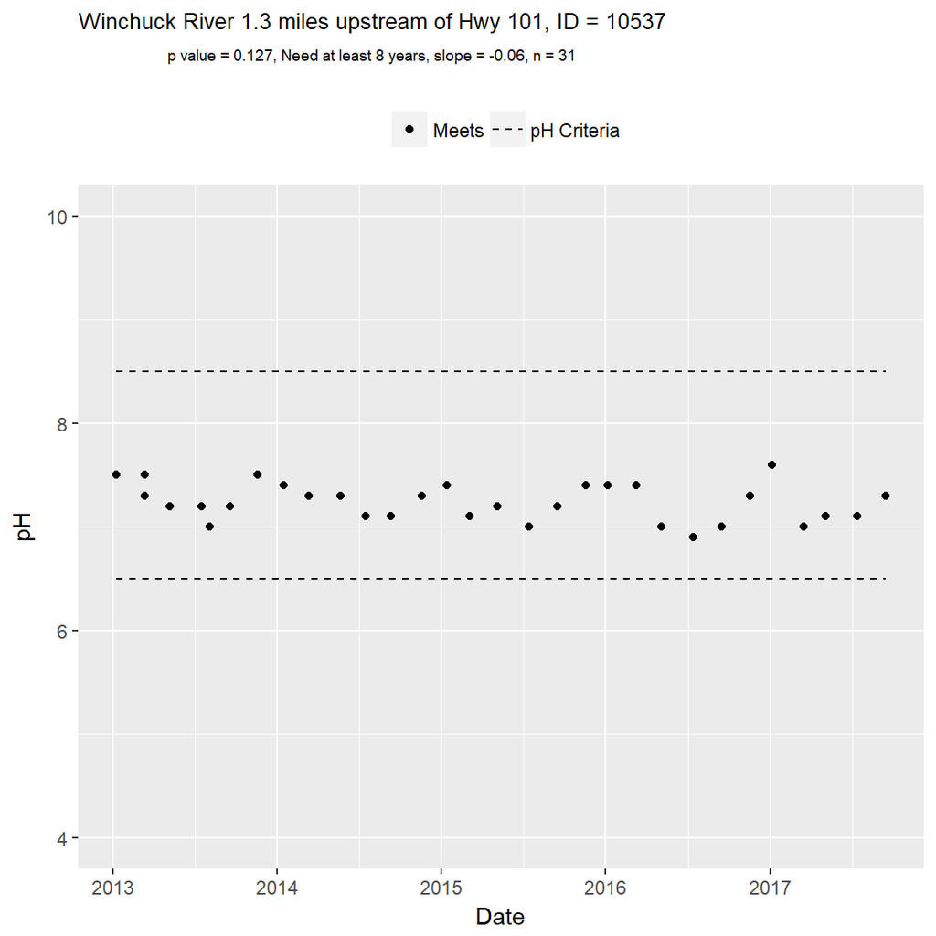

pH water quality status and trends

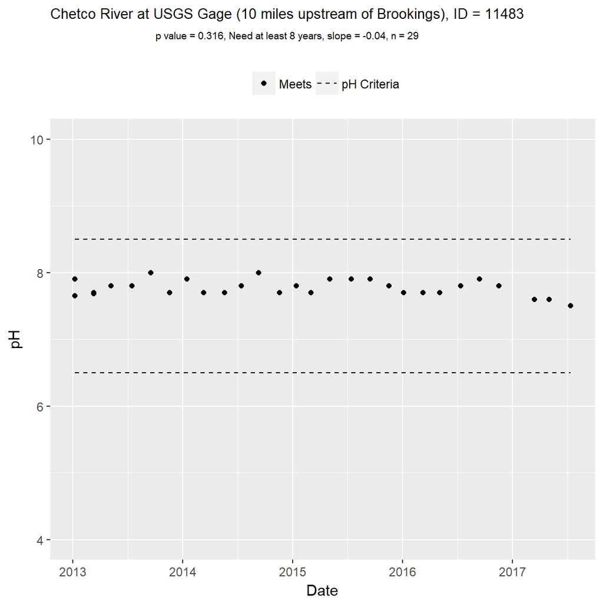

pH water quality status and trends

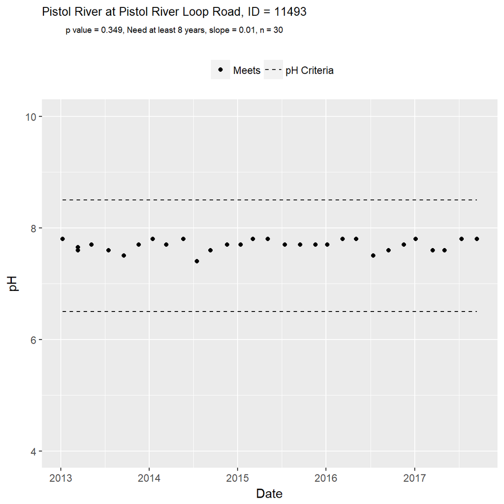

pH water quality status and trends

[output not shown]